# Midterm_Project_03

Julia Jin

11/1/2021

```r
donation <- read.csv(file='UniversityDonations.csv')
donation$Year <- as.factor(donation$Year)
summary(donation$Amount)
```

[output not shown]

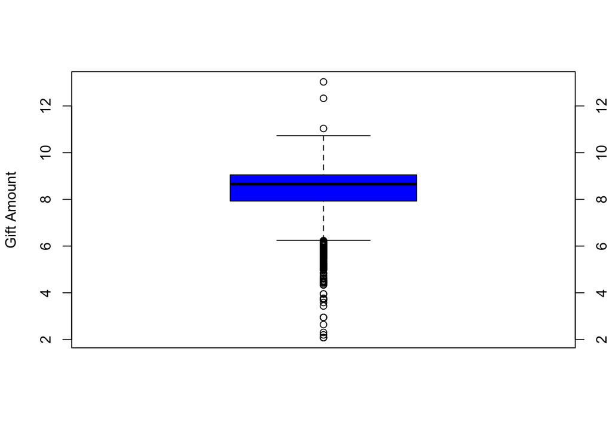

```r
boxplot(log(donation$Amount), col='blue', ylab="Gift Amount", title="University Donations")
axis(side = 4)
```

Obviously this is not normal.

Remove any outliers and test normality based on different subcategories.

```r
donation2 = outlierKD2(donation, Amount, rm=T, histogram = F)
```

```
## Outliers successfully removed
```

```r
str(donation2)
```

[output not shown]

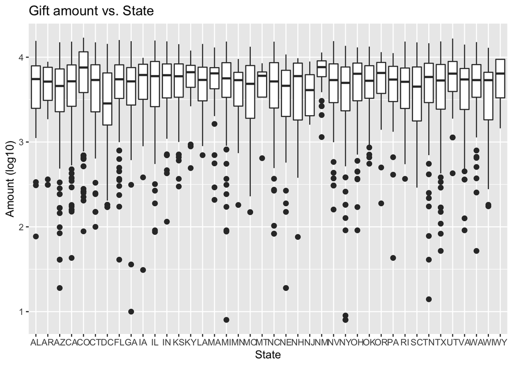

```r
loadPkg("ggplot2")
ggplot(donation2, aes(x=State, y=log10(Amount)))+geom_boxplot(outlier.size = 2)+labs(title = 'Gift amount vs. State', x='State', y='Amount (log10)')
```

```r
anovaState <- aov(log10(Amount)~State, data=donation2)
xkabledply(anovaState)
```

Model: log10(Amount) ~ State

|  | Df | Sum Sq | Mean Sq | F value | Pr(>F) |
| --- | --- | --- | --- | --- | --- |
| State | 39 | 20.6 | 0.529 | 2.79 | 0 |
| Residuals | 3782 | 715.9 | 0.189 | NA | NA |

The p-value is close to 0, so we reject our null hypothesis, meaning we can say at least in one state, the mean of gift amount is different than in the other states.

### Tukey

```r
tukeyState <- TukeyHSD(anovaState)
tukeyState
```

The full result is lengthy, so I will not display everything here. But following pairwise comparisons have p-value less than the standard 0.05: NE - CO, NY - CO, TX - CO So we can say that the mean of donation in Colorado is different from that in Nebraska, New York and Texas.

### vs. College

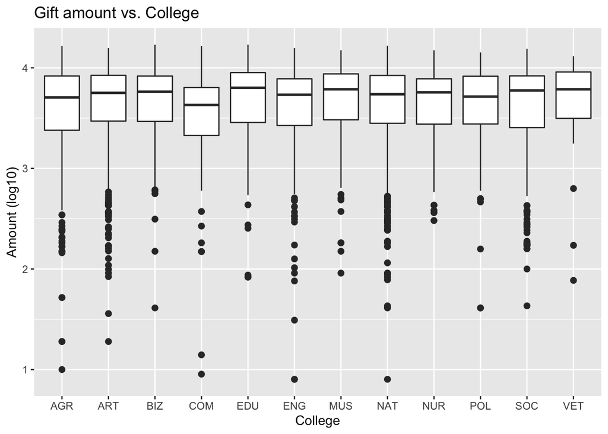

```r
ggplot(donation2, aes(x=College, y=log10(Amount)))+geom_boxplot(outlier.size = 2)+labs(title = 'Gift amount vs. College', x='College', y='Amount (log10)')
```

```r
anovaCollege <- aov(log10(Amount)~College, data=donation2)
xkabledply(anovaCollege)
```

Model: log10(Amount) ~ College

|  | Df | Sum Sq | Mean Sq | F value | Pr(>F) |
| --- | --- | --- | --- | --- | --- |
| College | 11 | 2.9 | 0.263 | 1.37 | 0.181 |
| Residuals | 3810 | 733.6 | 0.193 | NA | NA |

The p-value is 0.181 > 0.05, so we fail to reject the null hypothesis, meaning we can say the mean of gift amount among colleges are the same.

### vs. Year

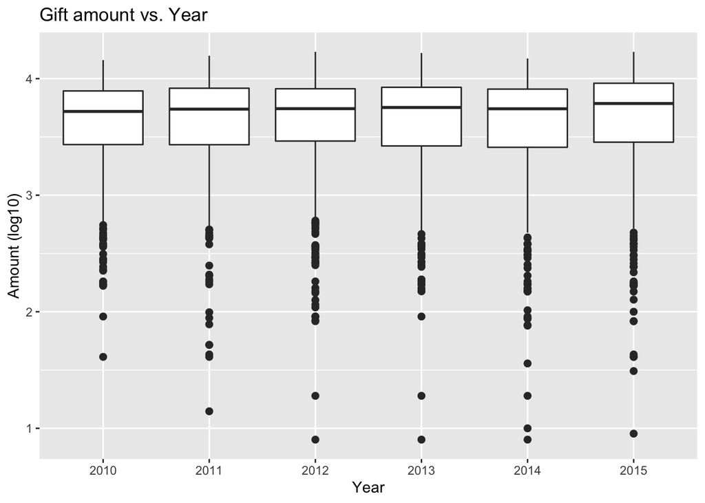

```r
ggplot(donation2, aes(x=Year, y=log10(Amount)))+geom_boxplot(outlier.size = 2)+labs(title = 'Gift amount vs. Year', x='Year', y='Amount (log10)')
```

```r
anovaYear <- aov(log10(Amount)~Year, data=donation2)
xkabledply(anovaYear)
```

Model: log10(Amount) ~ Year

|  | Df | Sum Sq | Mean Sq | F value | Pr(>F) |
| --- | --- | --- | --- | --- | --- |
| Year | 5 | 1.82 | 0.364 | 1.89 | 0.0925 |
| Residuals | 3816 | 734.68 | 0.193 | NA | NA |

The p-value is 0.0925 > 0.05, so we fail to reject the null hypothesis, meaning we can say the mean of gift amount received in different years are the same.

### vs. Allocation

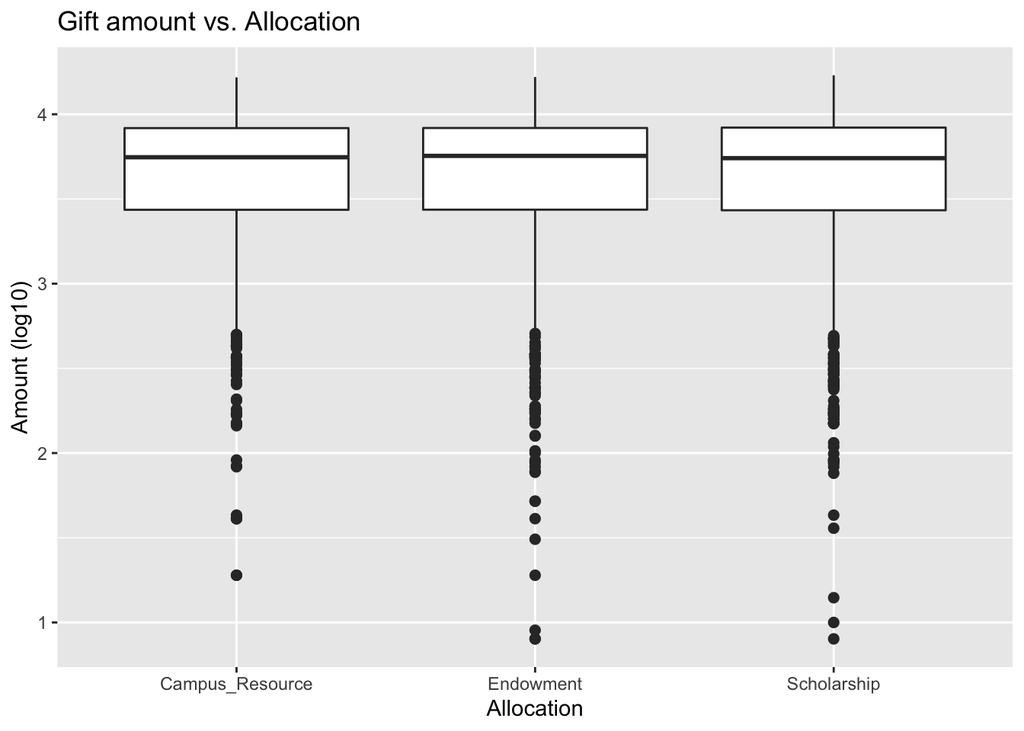

```r
ggplot(donation2, aes(x=Gift_Allocation, y=log10(Amount)))+geom_boxplot(outlier.size = 2)+labs(title = 'Gift amount vs. Allocation', x='Allocation', y='Amount (log10)')
```

```r
anovaAllocation <- aov(log10(Amount)~Gift_Allocation, data=donation2)
xkabledply(anovaAllocation)
```

Model: log10(Amount) ~ Gift_Allocation

|  | Df | Sum Sq | Mean Sq | F value | Pr(>F) |
| --- | --- | --- | --- | --- | --- |
| Gift_Allocation | 2 | 0.0893 | 0.0446 | 0.232 | 0.793 |
| Residuals | 3819 | 736.4127 | 0.1928 | NA | NA |

The p-value is 0.793 > 0.05, so we fail to reject the null hypothesis, meaning we can say the mean of gift amount with different allocations are the same.

Further subcategorize each allocation method.

```r
campus_resource <- subset(donation2, Gift_Allocation=='Campus_Resource')
endowment <- subset(donation2, Gift_Allocation=='Endowment')
scholarship <- subset(donation2, Gift_Allocation == 'Scholarship')
```

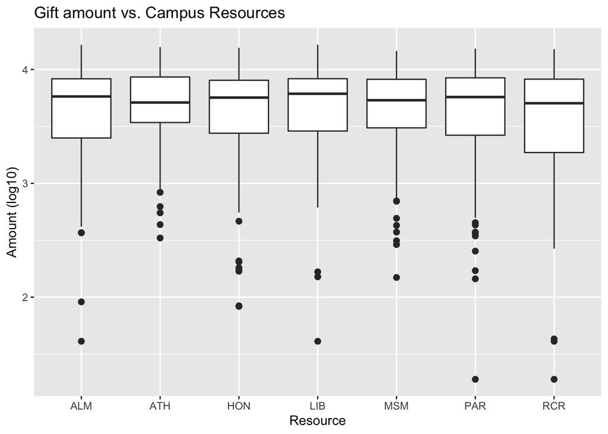

```r
ggplot(campus_resource, aes(x=Allocation_Subcategory, y=log10(Amount)))+geom_boxplot(outlier.size = 2)+labs(title = 'Gift amount vs. Campus Resources', x='Resource', y='Amount (log10)')
```

```r
anovaCampus <- aov(log(Amount)~Allocation_Subcategory, data=campus_resource)
xkabledply(anovaCampus)
```

Model: log(Amount) ~ Allocation_Subcategory

|  | Df | Sum Sq | Mean Sq | F value | Pr(>F) |
| --- | --- | --- | --- | --- | --- |
| Allocation_Subcategory | 6 | 8.97 | 1.49 | 1.38 | 0.222 |
| Residuals | 787 | 855.01 | 1.09 | NA | NA |

The p-value is 0.222 > 0.05, so we cannot reject our null hypothesis, meaning we can say the mean of gift amount among different resources are the same.

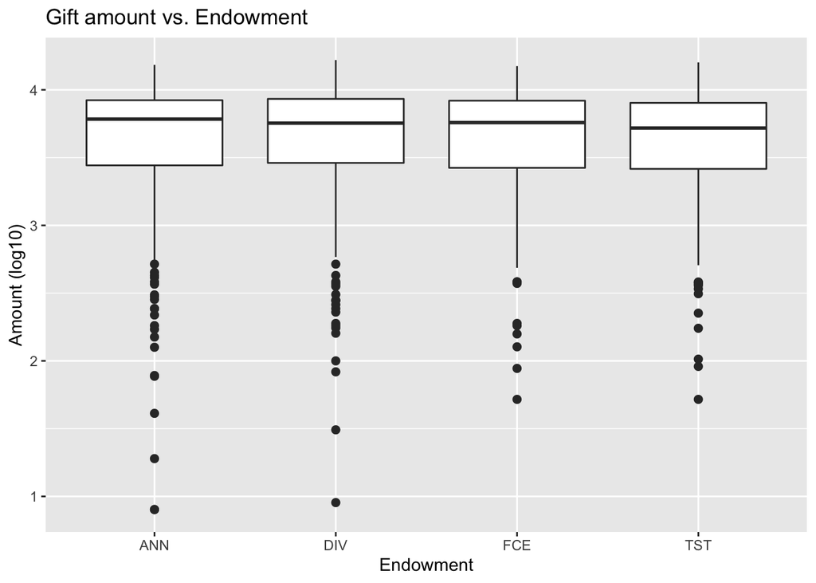

```r
ggplot(endowment, aes(x=Allocation_Subcategory, y=log10(Amount)))+geom_boxplot(outlier.size = 2)+labs(title = 'Gift amount vs. Endowment', x='Endowment', y='Amount (log10)')
```

```r
anovaEndowment <- aov(log10(Amount)~Allocation_Subcategory, data=endowment)
xkabledply(anovaEndowment)
```

Model: log10(Amount) ~ Allocation_Subcategory

|  | Df | Sum Sq | Mean Sq | F value | Pr(>F) |
| --- | --- | --- | --- | --- | --- |
| Allocation_Subcategory | 3 | 0.147 | 0.0491 | 0.253 | 0.859 |
| Residuals | 1373 | 266.501 | 0.1941 | NA | NA |

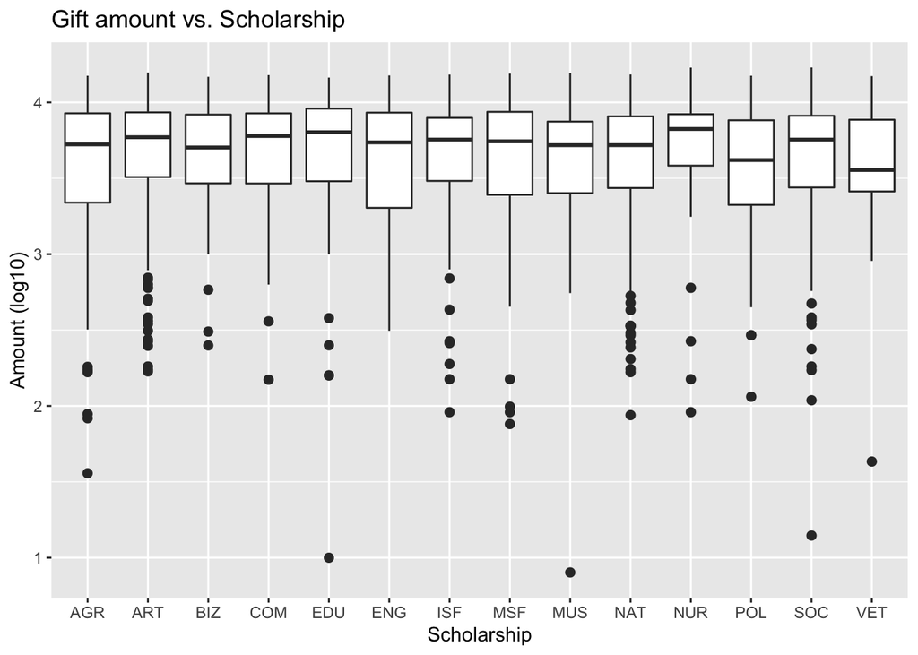

```r
ggplot(scholarship, aes(x=Allocation_Subcategory, y=log10(Amount)))+geom_boxplot(outlier.size = 2)+labs(title = 'Gift amount vs. Scholarship', x='Scholarship', y='Amount (log10)')
```

```r
anovaScholarship <- aov(log10(Amount)~Allocation_Subcategory, data=scholarship)
xkabledply(anovaScholarship)
```

Model: log10(Amount) ~ Allocation_Subcategory

|  | Df | Sum Sq | Mean Sq | F value | Pr(>F) |
| --- | --- | --- | --- | --- | --- |
| Allocation_Subcategory | 13 | 1.9 | 0.146 | 0.785 | 0.677 |
| Residuals | 1637 | 304.9 | 0.186 | NA | NA |

The p-value is 0.677 > 0.05, so we cannot reject our null hypothesis, meaning we can say the mean of gift amount among different resources is the same.